# Exam #1

2020-02-20

# Question 1

Consider the [Paris Treaty data](https://github.com/openclimatedata/paris-agreement-entry-into-force/tree/master/data) on when the Paris climate agreements were ratified and entered into force. We’ll use the “paris” data from the course’s Canvas [files/exam_1](https://canvas.harvard.edu/courses/64336/files/folder/exam_1) page. Download a copy of this data from the provided link, create a directory named “raw-data” within your project, and move the data (which should be called “paris.csv”) to that directory. (This is what you did with problem set #3, although you are using different data here.)

When you read in the data, use the `janitor` package to clean the filenames, so that you don’t have numeric column names.

1. The highest emissions are from the country X.
2. The number of countries that have neither ratified nor approved of the treaty is X. (Acceptance and accession do not count as approval).
3. The longest number of days between signature and ratification (for a country that has successfully ratified) is X days.
4. The number of ratifying countries whose name ends with “stan” is X.

Now access World Bank emissions data in the [exam 1](https://canvas.harvard.edu/courses/64336/files/folder/exam_1) folder on canvas. Download a copy of this data from the provided link, create a directory named “raw-data” within your project, and move the data (which should be called “WB_co2_emissions.csv”) to that directory. Commit those changes. Read in the data, clean the variable names using `janitor`, and then answer the following Mad Libs.

5. In 1960, the country with the highest emissions was X.
6. The average emissions in 2000 was X metric tons per capita. (Round so that there are only two digits after the decimal point.)

# Question 2

You’ll notice that the co2 data has one observation per country, and the data for each year is in its own column. In a *tidy* version of this data, a `country` column and a `year` column would serve as the key, and then we could have a single variable `emissions_per_capita` to capture all that data in the different columns.

Put your co2 data into tidy format. You may want to check out the `names_prefix` option in pivot_longer(). Your data should look something like this (but you don’t need to show us the table).

| country_name | code | indicator_name | indicator_code | year | emissions_per_capita |
| --- | --- | --- | --- | --- | --- |
| Afghanistan | AFG | CO2 emissions (metric tons per capita) | EN.ATM.CO2E.PC | 1999 | 0.04072254 |
| Afghanistan | AFG | CO2 emissions (metric tons per capita) | EN.ATM.CO2E.PC | 2000 | 0.03723478 |
| Afghanistan | AFG | CO2 emissions (metric tons per capita) | EN.ATM.CO2E.PC | 2001 | 0.03784614 |
| Afghanistan | AFG | CO2 emissions (metric tons per capita) | EN.ATM.CO2E.PC | 2002 | 0.04737732 |
| Afghanistan | AFG | CO2 emissions (metric tons per capita) | EN.ATM.CO2E.PC | 2003 | 0.05048134 |
| Afghanistan | AFG | CO2 emissions (metric tons per capita) | EN.ATM.CO2E.PC | 2004 | 0.03841004 |
| Afghanistan | AFG | CO2 emissions (metric tons per capita) | EN.ATM.CO2E.PC | 2005 | 0.05174397 |
| Afghanistan | AFG | CO2 emissions (metric tons per capita) | EN.ATM.CO2E.PC | 2006 | 0.06242753 |
| Afghanistan | AFG | CO2 emissions (metric tons per capita) | EN.ATM.CO2E.PC | 2007 | 0.08389281 |
| Afghanistan | AFG | CO2 emissions (metric tons per capita) | EN.ATM.CO2E.PC | 2008 | 0.15172091 |
| Afghanistan | AFG | CO2 emissions (metric tons per capita) | EN.ATM.CO2E.PC | 2009 | 0.23839854 |

Now, join your Paris data to your new co2 data, using the year and country code.

Using your joined data, make a graphic which uses emissions per capita (from the co2 tibble) and the date the Paris treaty took effect: `date_of_effect`. You may use other variables if you wish. Note that you do not, by any means, need to include all the data in your graphic. Perhaps you want to pick a single country code, and show us its emissions over time and the date of ratification, like we do in our Mexico example below. Perhaps you want to show us each country’s emissions in the year that the treaty took effect. There is no right answer. But you should have many, many code comments discussing the choices you made, why you made them and what other options you considered. Make a graphic of which Healy would approve.

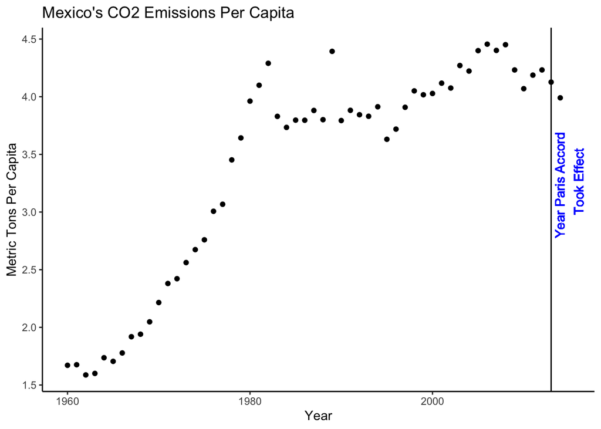

# Question 3

We have discussed causal inference, potential outcomes and the Rubin Causal Model in class. (If you are unsure about these concepts, I *highly* recommend [the Rubin Causal Model](https://davidkane9.github.io/PPBDS/A-rubin-causal-model.html), in the appendix of *PPBDS*)

Let’s imagine that we’re going to try a new experiment on the Paris data that we first uploaded. In our experiment, we give all the countries whose name starts with a vowel $1 billion to fight climate change. The treatment is receiving the money; the control is not receiving the money. The sample is restricted to only countries that have ratified the Paris treaty (You should have 176 countries). The outcome is emissions per capita.

Using the *gt* package, create a potential outcomes table which captures the setup associated with our experiment. This is a very similar process to what you did on problem set 3, although you’ll first have to assign treatment based on the rules above. In your table, you do not need to show every observation of the dataset, but you should show enough to prove that you assigned treatment correctly. The point of this question is for you to demonstrate that you understand the potential outcomes framework.

Write a short (fewer than 200 words- parsimony is a virtue!) paragraph which explains the potential outcomes table in the context of this experiment. Try and imagine that this is for a presentation to an audience that knows nothing about the Rubin Causal framework. How would you explain this table? Specifically, make sure to tell us:

- What is the **causal effect** you are trying to measure?
- What is the **assignment mechanism** being used? Do you think it is random enough to accurately measure the effect?
- Why are there question marks in half of the table?